# Analysis of Uni- and Multi-Dimensional Contours with GAMs and Functional PCA: an Application to Ultrasound Tongue Imaging

Author

Affiliation

Michele Gubian

Institute for Phonetics and Speech Processing,  
Ludwig Maximilian University, Munich

Published

April 24, 2025

Loading libraries and a few helper scripts.

```r
# data processing and plotting
library(tidyverse)
# GAMs
library(mgcv)
library(itsadug)
# FPCA
library(funData)
library(MFPCA)
# install.packages("devtools")
# devtools::install_github("uasolo/landmarkregUtils")
library(landmarkregUtils)
library(abind)
# LMER
library(lme4)
library(emmeans)
# plotting
library(RColorBrewer)
library(gridExtra)
source("polar_utils.R")
# artificial UTI data generator
source("parab_tongue.R")
# cosmetics
Category.colors <- c(A = "black", B = "limegreen")
theme_set(theme_light())
```

# 1 Static analysis

Static refers to absence of time. The typical scenario is the analysis of UTI where only one representative contour is used for each speech sound, e.g. the onset or the point in time where the articulatory target is reached.

## 1.1 Data generation

This tutorial is based on artificial data. The helper function `parab_tongue()` generates curves that resemble tongue contours. The shape consists of two branches of parabolas joined at the vertex. The shape is parametrised so that it can vary in various ways. The output is a tibble with three columns: `knot`, `x` and `y`, where `knot` simulates the (11) knots obtained with DeepLabCut (Wrench & Balch-Tomes 2022). See the source code `parab_tongue.R` for more detail.

**Data generation demo**

```r
curve <- parab_tongue(
  a_left = 2,
  a_right = 1,
  npoints = 11, # knots
  scale = c(10, 5),
  centre = c(50,80),
  theta = pi/12
)
print(curve)
```

```
# A tibble: 11 × 3
    knot     x     y
   <int> <dbl> <dbl>
 1     1  51.4  38.8
 2     2  47.8  53.2
 3     3  45.9  64.5
 4     4  45.6  72.8
 5     5  47.0  77.9
 6     6  50    80
 7     7  54.3  79.7
 8     8  59.4  77.9
 9     9  65.3  74.6
10    10  72.1  69.7
11    11  79.7  63.3
```

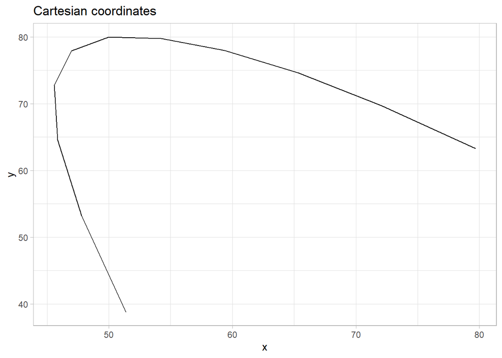

```r
ggplot(curve) +
  aes(x, y) +
  geom_path() +
  ggtitle("Cartesian coordinates")
```

## 1.2 Polar coordinates

The $(x, y)$ coordinates are usually not suitable for a classic $y = f(x)$ model, as the tongue contour in some regions has more than one $y$ value corresponding to the same $x$, which is incompatible with a standard function, e.g. with a GAM `y ~ s(x)`. The polar coordinate representation mitigates this problem, as most of the time $radius = f(angle)$ is well behaved.

In order to transform $(x, y)$ coordinates into polar ones we need to specify an origin point. Here the location of the origin will be chosen by eye inspection. The helper function `cart2polar()` performs the transformation, while `radial_plot()` is a plotting helper.

**Polar coordinates demo**

```r
# convert to polar
origin <-  c(70, 30) # eye inspection
curve <- curve %>%
  cart2polar(origin, 'x', 'y')

print(curve)
```

```
# A tibble: 11 × 5
    knot     x     y angle radius
   <int> <dbl> <dbl> <dbl>  <dbl>
 1     1  51.4  38.8  2.70   20.6
 2     2  47.8  53.2  2.33   32.1
 3     3  45.9  64.5  2.18   42.1
 4     4  45.6  72.8  2.09   49.3
 5     5  47.0  77.9  2.02   53.2
 6     6  50    80    1.95   53.9
 7     7  54.3  79.7  1.88   52.2
 8     8  59.4  77.9  1.79   49.1
 9     9  65.3  74.6  1.68   44.8
10    10  72.1  69.7  1.52   39.8
11    11  79.7  63.3  1.29   34.6
```

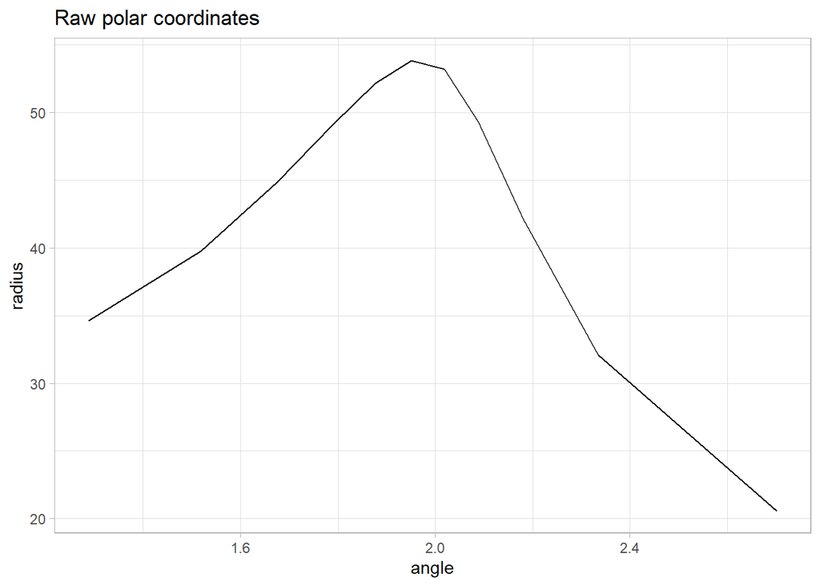

```r
# plot raw polar
ggplot(curve) +
  aes(angle, radius) +
  geom_path() +
  ggtitle("Raw polar coordinates")
```

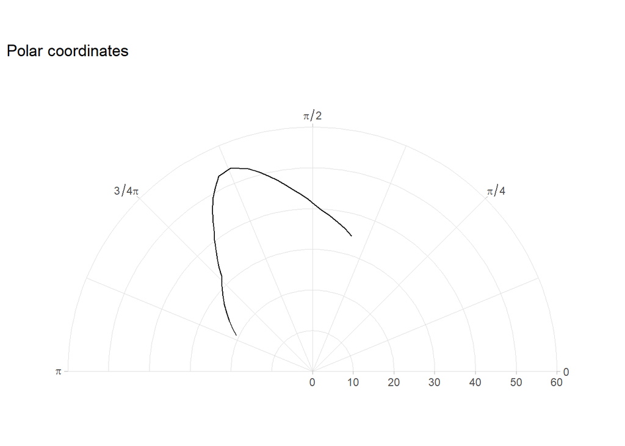

```r
# plot polar
ggplot(curve) +
  aes(angle, radius) +
  geom_path() +
  radial_plot(60) +
  ggtitle("Polar coordinates")
```

## 1.3 Dataset

The dataset for the static analysis consists of 60 artificial tongue contours, 30 for each `Category`, `A` and `B`. This is the simplest possible scenario, with only one categorical predictor with two levels and no random factors. Hints on adaptations for more complex and realistic scenarios will be provided throughout the exposition.

**Dataset generation**

```r
set.seed(123)
N_curves_per_Category <- 30
raw_curves <- tibble(
  Category = c('A', 'B'),
  a_left_off = c(1, 1),
  a_right_off = c(1, 1),
  theta_off = c(-pi/12, 0),
  scale_x_off = c(1,1),
  centre_x_off = c(10,0),
  centre_y_off = c(0,0)
) %>%
  expand_grid(i = 1:N_curves_per_Category) %>%
  rownames_to_column(var = "frame_id") %>%
  mutate(frame_id = as.integer(frame_id)) %>%
  select(-i) %>%
  mutate(across(c(Category, frame_id), ~ factor(.x))) %>%
  group_by(Category, frame_id) %>%
  reframe(parab_tongue(
    a_left = 1.2 * a_left_off * runif(1, 1/1.1, 1.1),
    a_right = 0.3 * a_right_off * runif(1, 1/1.4, 1.4),
    centre = c(50 + centre_x_off + runif(1, 0, 5),
               80 + centre_y_off + runif(1, 0, 5)),
    theta = pi/18 + theta_off + runif(1, -pi/12, pi/12),
    scale =  c(10 * scale_x_off * runif(1, 1/1.1, 1.1), 5)
  ))

dataset_xy_plot <- ggplot(raw_curves) +
  aes(x, y, group = frame_id, color = Category) +
  geom_path() +
  scale_color_manual(values=Category.colors)

# convert to polar
origin <-  c(70, 30) # eye inspection
raw_curves  <- raw_curves  %>%
  cart2polar(origin, 'x', 'y')

dataset_polar_plot <- ggplot(raw_curves ) +
  aes(angle, radius, group = frame_id, color = Category) +
  geom_path() +
  scale_color_manual(values=Category.colors) +
  radial_plot(60) +
  theme(legend.position = "bottom")
```

Figure 1: Dataset in (x,y) coordinates

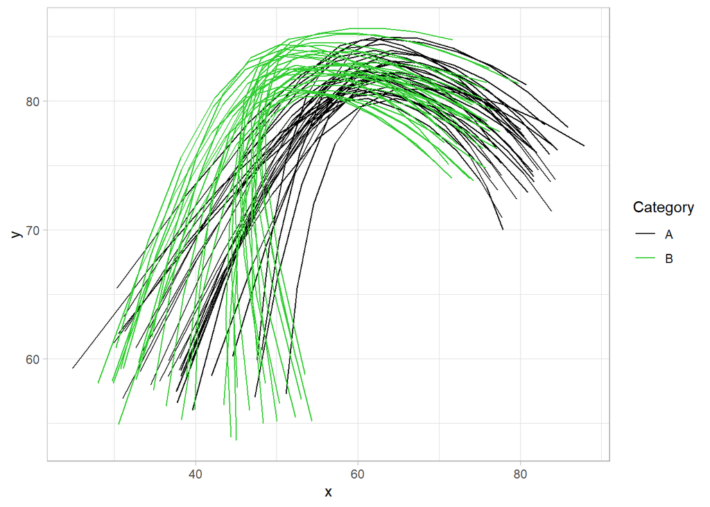

```r
dataset_xy_plot
```

Figure 2: Dataset in polar coordinates

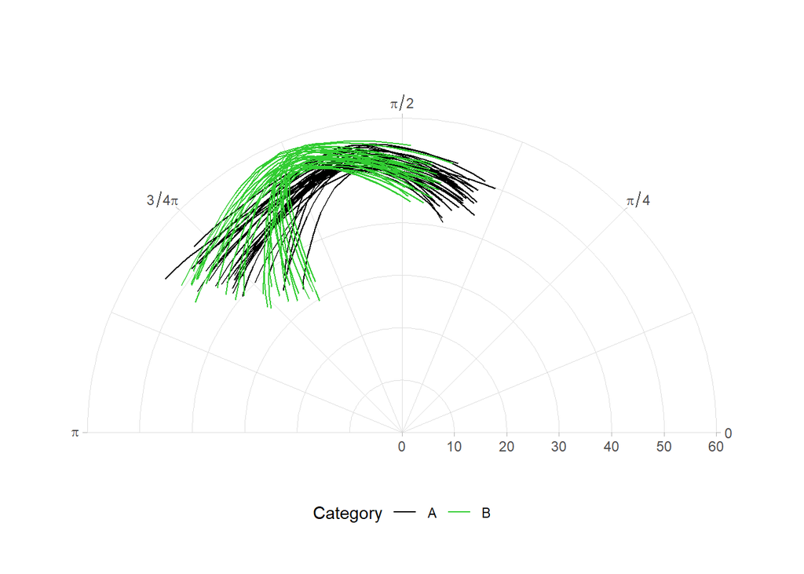

```r
dataset_polar_plot
```

## 1.4 radius ~ angle: GAM

Here we fit a GAM to the dataset, using the polar representation. This means that we predict `radius` given `angle` and `Category`. As `angle` is a continuous variable, this will be modelled with smooth terms `s()`.

GAM fitting is carried out with a simple, standard procedure. Essentially, we first fit a minimal model without AR1 (autoregressive) term, from which we estimate an AR1 term that is used for a second fit. The rest of the model parameters are set using default values. A scaled-t residual family is used whenever possible. Model fitting, diagnostics and inference are generally based on Wieling (2018), to which the reader is referred for a general introduction on GAMs. For more complex predictor structure, including random terms, see Wieling (2018) and the tutorial materials on [this GitHub](https://github.com/uasolo/FPCA-phonetics-workshop/tree/master/presentations/GAMs).

**radius ~ angle: GAM fit**

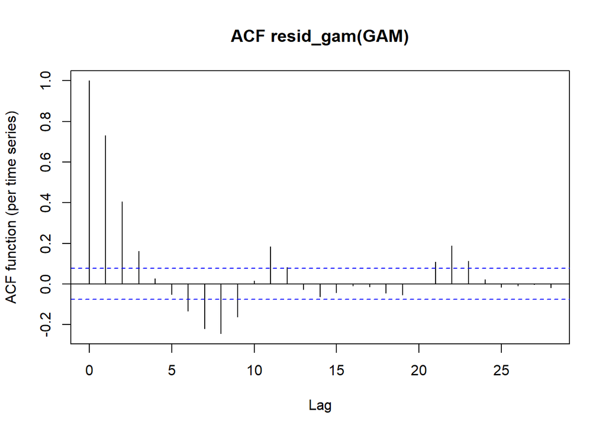

```r
curves  <- raw_curves  # convenience for code reuse
gam_formula <- "radius ~ Category + s(angle, by = Category)"
GAM <- bam(gam_formula %>% as.formula(),
            discrete = TRUE,
            family = 'scat',
            data = curves
)
AR1.rho <- acf_resid(GAM)[2]
```

```r
GAM <- bam(gam_formula %>% as.formula(),
            discrete = TRUE,
            family = 'scat',
            rho = AR1.rho,
            AR.start = curves %>% pull(knot)  == 1,
            data = curves
)
summary(GAM)
```

```
Family: Scaled t(3,2.106)
Link function: identity

Formula:
radius ~ Category + s(angle, by = Category)

Parametric coefficients:
            Estimate Std. Error t value Pr(>|t|)
(Intercept)  49.6743     0.3149 157.762  < 2e-16 ***
CategoryB     1.5248     0.4423   3.448 0.000602 ***
---
Signif. codes:  0 '***' 0.001 '**' 0.01 '*' 0.05 '.' 0.1 ' ' 1

Approximate significance of smooth terms:
                     edf Ref.df     F p-value
s(angle):CategoryA 6.775  8.014 31.71  <2e-16 ***
s(angle):CategoryB 7.092  7.965 35.61  <2e-16 ***
---
Signif. codes:  0 '***' 0.001 '**' 0.01 '*' 0.05 '.' 0.1 ' ' 1

R-sq.(adj) =  0.358   Deviance explained = 35.6%
fREML = 929.69  Scale est. = 1         n = 660
```

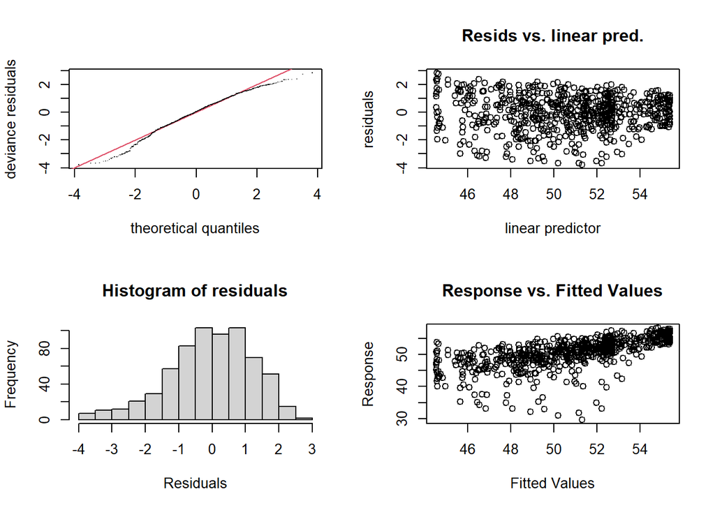

```
Method: fREML   Optimizer: perf chol
$grad
[1] -1.339989e-07 -1.995888e-06

$hess
             [,1]          [,2]
[1,] 2.826731e+00 -2.113013e-18
[2,] 4.882741e-31  2.598469e+00

Model rank =  20 / 20

Basis dimension (k) checking results. Low p-value (k-index<1) may
indicate that k is too low, especially if edf is close to k'.

                     k'  edf k-index p-value
s(angle):CategoryA 9.00 6.78    0.87   0.005 **
s(angle):CategoryB 9.00 7.09    0.87  <2e-16 ***
---
Signif. codes:  0 '***' 0.001 '**' 0.01 '*' 0.05 '.' 0.1 ' ' 1
```

```r
gam.check(GAM)
```

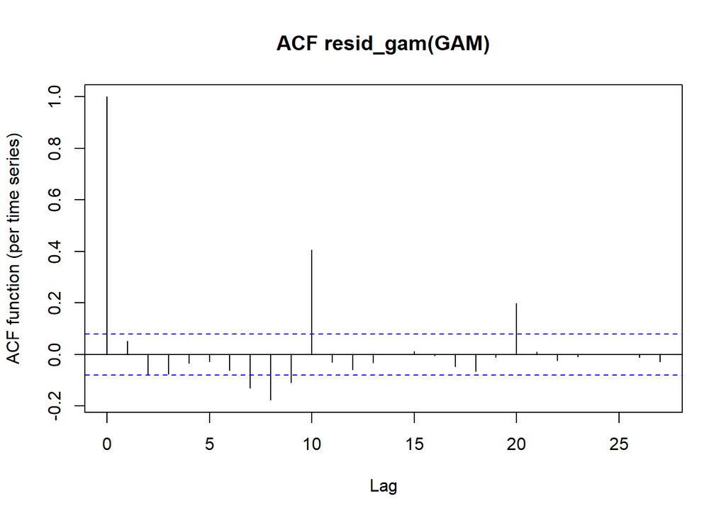

```r
acf_resid(GAM)
```

```r
angle_grid_plot <- seq(min(curves$angle), max(curves$angle), length.out = 20)
pred <- get_predictions(GAM,
                        cond = list(angle = angle_grid_plot, Category = c("A", "B")),
                        print.summary = FALSE)

gam_polar_plot <- ggplot(pred) +
  aes(x = angle, y = fit, group = Category ) +
  geom_line(mapping = aes(color = Category)) +
  scale_color_manual(values=Category.colors) +
  scale_fill_manual(values=Category.colors) +
  geom_ribbon(mapping = aes(ymin = fit - CI, ymax = fit + CI, fill = Category), alpha = 0.5) +
  radial_plot(60) +
  theme(legend.position = "bottom")
```

Figure 3: GAM predicted contours

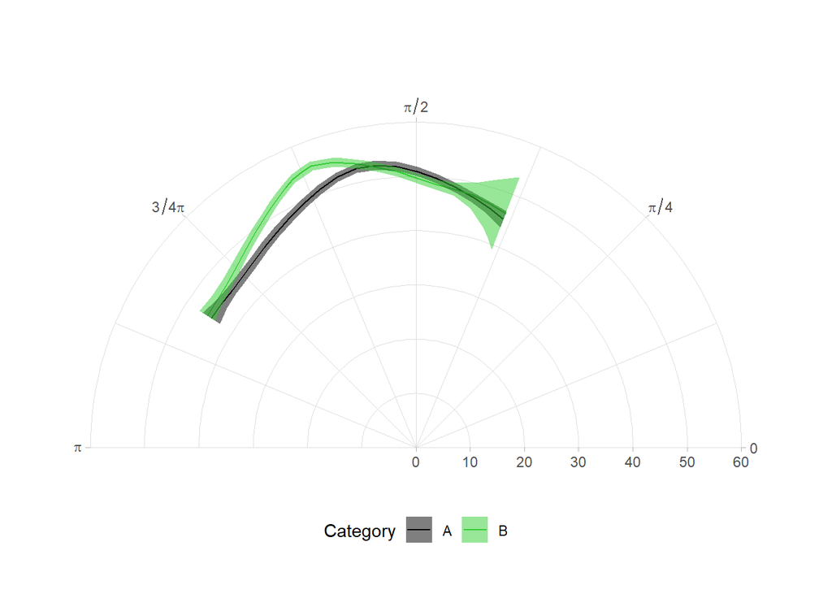

```r
gam_polar_plot
```

The contour shapes capture the characteristics of the original dataset fairly well. A few observations:

- The original data presents high variation at the left (tongue root), which is not visible in the predicted contours. This is because the confidence bands reflect the uncertainty in the estimation of the **mean** contours, not the extra unexplained noise (the same principle applies to ordinary linear regression estimates, e.g. `lm()`)
- The right extreme of the `B` contour has a wide confidence band. This is because the `B` contours end early at the right (tongue tip) in the original dataset, hence there are not enough data points to perform accurate estimations.

To overcome the second issue, two simple approaches can be applied:

- linear angle normalization
- Procrustean fit

where Procrustean means that we establish a fixed angle range for all contours, cut off the points that are beyond that range and extrapolate points for contours that do not have values up to the range limits.

Both approaches are quite simple, yet can introduce problems. Cutting extremes eliminates information, e.g. part of the tongue tip is removed from some contours. Linear angle normalization distorts the shape of the contour.

### 1.4.1 Linear angle normalization

A simple way to establish the reference angle range is to take the median angle of the first/last point from all contours. The contours are then reinterpolated on a regular grid within the common angle range. This of course introduces approximations, including the fact that now knots lose their original interpretation. However, a regular grid offers computational advantages, especially for FPCA (see below).

Below we apply linear angle normalization, then re-fit the GAM in the same way as above.

**Linear angle normalization**

```r
angle_range <- raw_curves  %>%
  filter(knot %in% range(knot)) %>% # first and last knot
  group_by(knot) %>%
  summarise(median_angle = median(angle)) %>%
  pull(median_angle) %>%
  sort()

angle_grid <- seq(angle_range[1], angle_range[2], length.out=11)

curves  <- raw_curves  %>%
  group_by(Category, frame_id) %>%
  # linear angle normalization on the angle_range interval
  mutate(angle = (angle - min(angle)) * diff(angle_range) / diff(range(angle)) + angle_range[1]) %>%
  # linear interpolation on angle_grid (optional for GAM)
  reframe(bind_cols(
    knot = seq_along(angle_grid), # fake knots, needed for AR1 term in GAM
    approx(angle, radius, angle_grid) %>% as_tibble()
    )) %>%
  rename(angle = x, radius = y)
```

**radius ~ angle: GAM fit linear angle normalization**

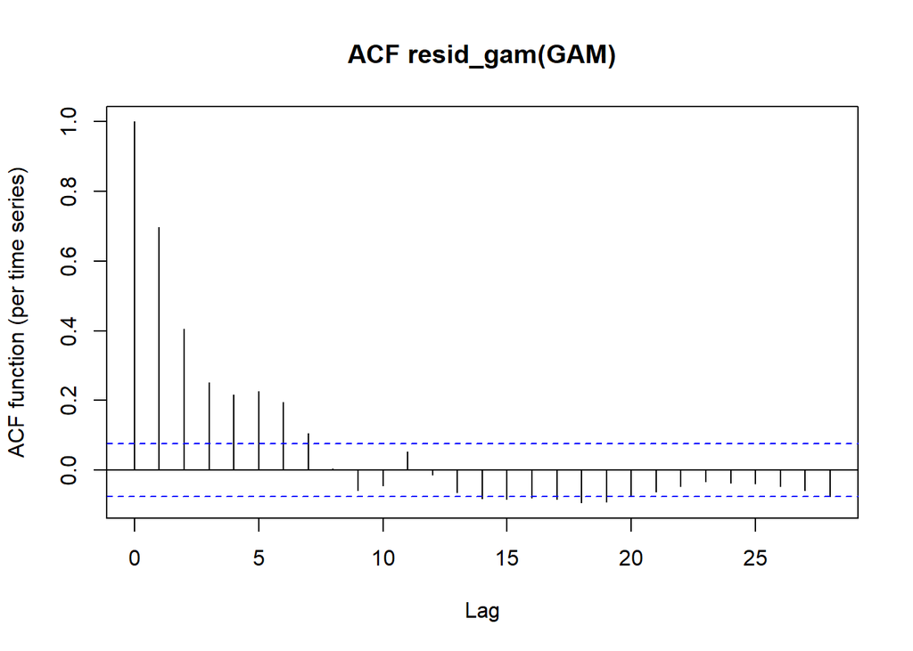

```r
gam_formula <- "radius ~ Category + s(angle, by = Category)"
GAM <- bam(gam_formula %>% as.formula(),
            discrete = TRUE,
            family = 'scat',
            data = curves
)
AR1.rho <- acf_resid(GAM)[2]
```

```r
GAM <- bam(gam_formula %>% as.formula(),
            discrete = TRUE,
            family = 'scat',
            rho = AR1.rho,
            AR.start = curves %>% pull(knot)  == 1,
            data = curves
)
summary(GAM)
```

```
Family: Scaled t(3.443,1.978)
Link function: identity

Formula:
radius ~ Category + s(angle, by = Category)

Parametric coefficients:
            Estimate Std. Error t value Pr(>|t|)
(Intercept)  49.0856     0.2726 180.042  < 2e-16 ***
CategoryB     1.4200     0.3856   3.682 0.000251 ***
---
Signif. codes:  0 '***' 0.001 '**' 0.01 '*' 0.05 '.' 0.1 ' ' 1

Approximate significance of smooth terms:
                     edf Ref.df      F p-value
s(angle):CategoryA 6.678  7.978  39.06  <2e-16 ***
s(angle):CategoryB 7.818  8.707 140.19  <2e-16 ***
---
Signif. codes:  0 '***' 0.001 '**' 0.01 '*' 0.05 '.' 0.1 ' ' 1

R-sq.(adj) =  0.624   Deviance explained = 48.8%
fREML = 917.82  Scale est. = 1         n = 660
```

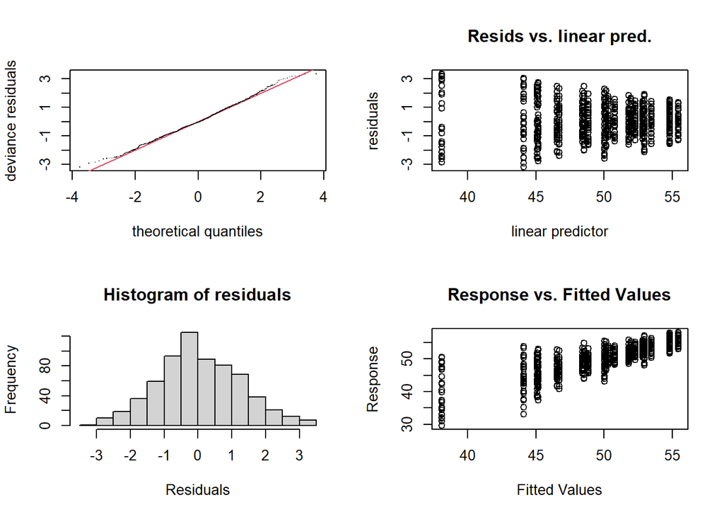

```
Method: fREML   Optimizer: perf chol
$grad
[1] 9.204291e-10 2.899667e-09

$hess
              [,1]          [,2]
[1,]  3.088541e+00 -1.197073e-18
[2,] -1.503855e-19  3.610893e+00

Model rank =  20 / 20

Basis dimension (k) checking results. Low p-value (k-index<1) may
indicate that k is too low, especially if edf is close to k'.

                     k'  edf k-index p-value
s(angle):CategoryA 9.00 6.68    0.95    0.12
s(angle):CategoryB 9.00 7.82    0.95    0.15
```

```r
gam.check(GAM)
```

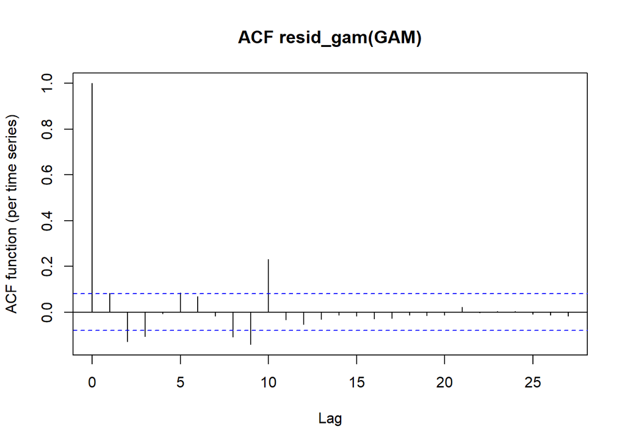

```r
acf_resid(GAM)
```

```r
angle_grid_plot <- angle_grid
pred <- get_predictions(GAM,
                        cond = list(angle = angle_grid_plot, Category = c("A", "B")),
                        print.summary = FALSE)

gam_polar_lin_plot <- ggplot(pred) +
  aes(x = angle, y = fit, group = Category ) +
  geom_line(mapping = aes(color = Category)) +
  scale_color_manual(values=Category.colors) +
  scale_fill_manual(values=Category.colors) +
  geom_ribbon(mapping = aes(ymin = fit - CI, ymax = fit + CI, fill = Category), alpha = 0.5) +
  radial_plot(60) +
  theme(legend.position = "bottom")
```

Figure 4: GAM predicted contours, linear angle normalization

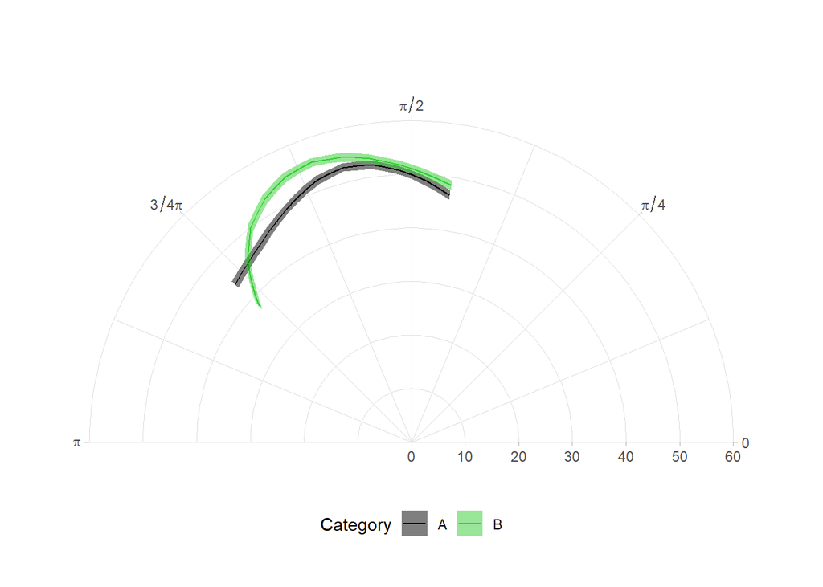

```r
gam_polar_lin_plot
```

In this case, Category B’s tongue tip reaches the same angle as A, which is not the case in the real data set. This is an artefact introduced by the linear stretching along the angle axis.

### 1.4.2 Procrustean angle range

As an alternative to linear angle normalization, we apply a Procrustean angle interpolation using the same angle range estimated above.

**Procrustean angle range**

```r
curves  <- raw_curves  %>%
  group_by(Category, frame_id) %>%
  # interpolation
  reframe(bind_cols(
    knot = seq_along(angle_grid), # fake knots, needed for AR1 term in GAM
    approx(angle, radius, angle_grid, rule = 2) %>% as_tibble()
    )) %>%
  rename(angle = x,radius = y)
```

**radius ~ angle: GAM fit Procrustean angle range**

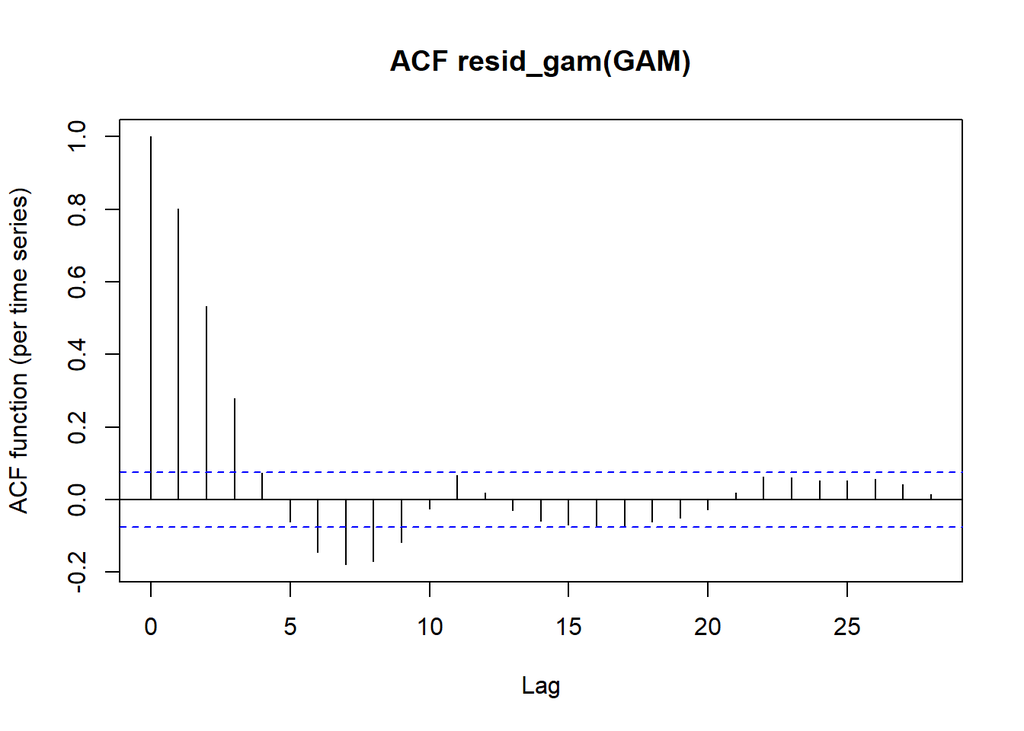

```r
gam_formula <- "radius ~ Category + s(angle, by = Category)"
GAM <- bam(gam_formula %>% as.formula(),
            discrete = TRUE,
            family = 'scat',
            data = curves
)
AR1.rho <- acf_resid(GAM)[2]
```

```r
GAM <- bam(gam_formula %>% as.formula(),
            discrete = TRUE,
            family = 'scat',
            rho = AR1.rho,
            AR.start = curves %>% pull(knot)  == 1,
            data = curves
)
summary(GAM)
```

```
Family: Scaled t(3,2.602)
Link function: identity

Formula:
radius ~ Category + s(angle, by = Category)

Parametric coefficients:
            Estimate Std. Error t value Pr(>|t|)
(Intercept)  49.1431     0.4195 117.134   <2e-16 ***
CategoryB     0.3712     0.5935   0.625    0.532
---
Signif. codes:  0 '***' 0.001 '**' 0.01 '*' 0.05 '.' 0.1 ' ' 1

Approximate significance of smooth terms:
                     edf Ref.df     F p-value
s(angle):CategoryA 6.292  7.671 21.55  <2e-16 ***
s(angle):CategoryB 7.760  8.683 88.45  <2e-16 ***
---
Signif. codes:  0 '***' 0.001 '**' 0.01 '*' 0.05 '.' 0.1 ' ' 1

R-sq.(adj) =   0.43   Deviance explained =   33%
fREML = 852.65  Scale est. = 1         n = 660
```

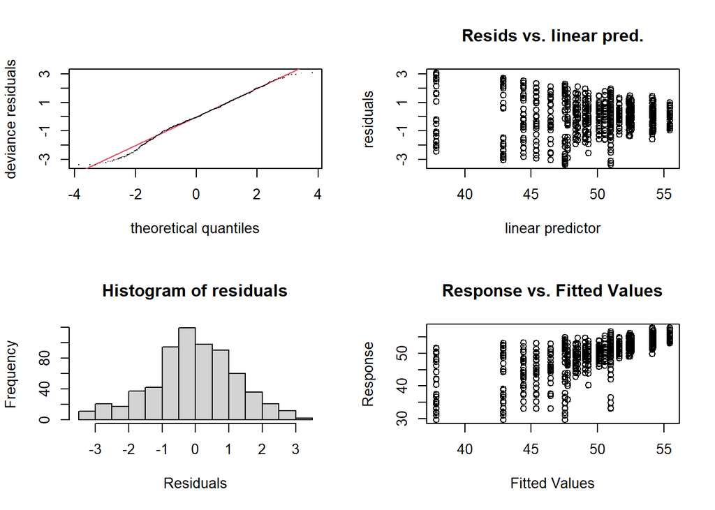

```
Method: fREML   Optimizer: perf chol
$grad
[1] -1.423750e-12  7.857182e-11

$hess
             [,1]          [,2]
[1,] 2.823996e+00 -3.510719e-19
[2,] 9.333367e-20  3.211993e+00

Model rank =  20 / 20

Basis dimension (k) checking results. Low p-value (k-index<1) may
indicate that k is too low, especially if edf is close to k'.

                     k'  edf k-index p-value
s(angle):CategoryA 9.00 6.29    0.94   0.020 *
s(angle):CategoryB 9.00 7.76    0.94   0.035 *
---
Signif. codes:  0 '***' 0.001 '**' 0.01 '*' 0.05 '.' 0.1 ' ' 1
```

```r
gam.check(GAM)
```

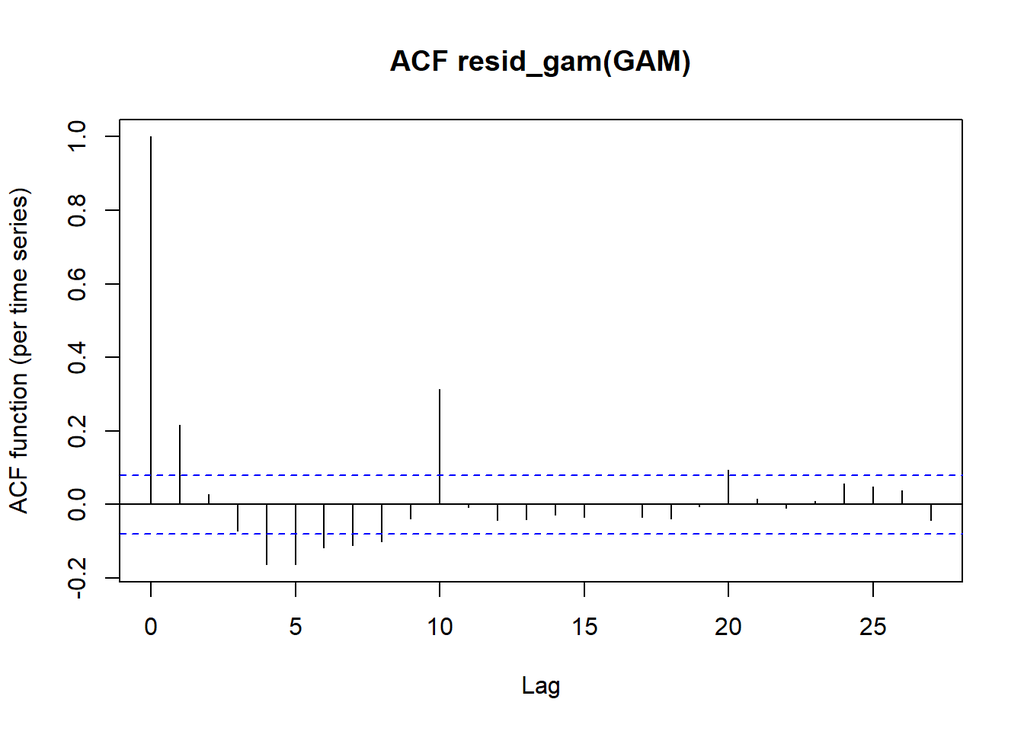

```r
acf_resid(GAM)
```

```r
angle_grid_plot <- angle_grid
pred <- get_predictions(GAM,
                        cond = list(angle = angle_grid_plot, Category = c("A", "B")),
                        print.summary = FALSE)

gam_polar_proc_plot <- ggplot(pred) +
  aes(x = angle, y = fit, group = Category ) +
  geom_line(mapping = aes(color = Category)) +
  scale_color_manual(values=Category.colors) +
  scale_fill_manual(values=Category.colors) +
  geom_ribbon(mapping = aes(ymin = fit - CI, ymax = fit + CI, fill = Category), alpha = 0.5) +
  radial_plot(60) +
  theme(legend.position = "bottom")
```

Figure 5: GAM predicted contours, Procrustean fit

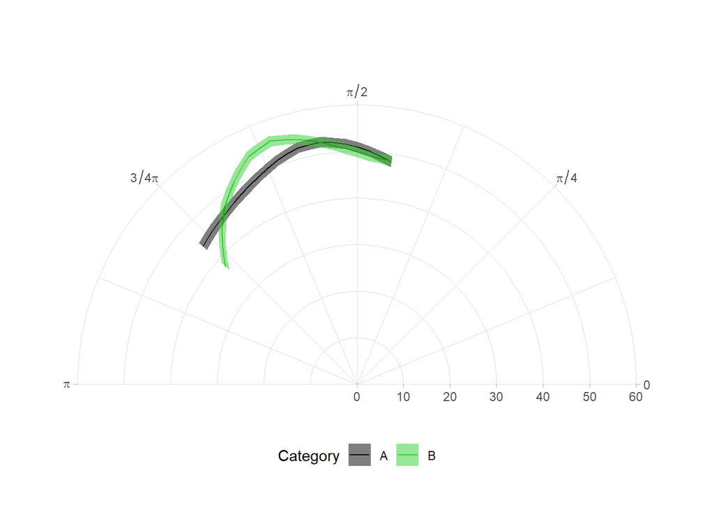

```r
gam_polar_proc_plot
```

Some of the information related to the tongue tip has been lost. Perhaps this is the reason why the GAM’s explained deviance is reduced. However, the predicted contours have a closer resemblance to the original dataset than in the linear angle normalization version, which introduced distortions in the contour shape.

In the rest of the tutorial, we will always use the Procrustean method. It is up to the user to choose the method most appropriate for the data at hand.

### 1.4.3 Testing for significance: binary smooths

Here we aim at showing if and where on the angle axis the difference between `Category` `A` and `B` is significant, and in which direction it goes. A graphical command is available for this (`itsadug::plot_diff`). Here instead we use a more general technique based on binary smooths (Wieling 2018), which consists in explicitly defining a curve as the difference between two given factor levels (in our case `B - A`), and then use its confidence interval to determine whether the difference is significantly different from zero. This approach can be applied also in more complex inference situations, e.g. difference of differences, see Wieling (2018) and [GAMInteractions](https://github.com/uasolo/FPCA-phonetics-workshop/tree/master/presentations/GAMs) for more detail.

**Binary smooths**

```r
# define a binary variable to indicate class B (as in Wieling 2018)
curves <- curves %>%
  mutate(IsB = (Category == 'B') * 1)
# the GAM equation contains a difference smooth representing B - A
gam_formula <- "radius ~ s(angle) + s(angle, by = IsB)"
GAM <- bam(gam_formula %>% as.formula(),
            discrete = TRUE,
            family = 'scat',
            rho = AR1.rho,
            AR.start = curves %>% pull(knot)  == 1,
            data = curves
)
summary(GAM)
```

```
Family: Scaled t(3,2.603)
Link function: identity

Formula:
radius ~ s(angle) + s(angle, by = IsB)

Parametric coefficients:
            Estimate Std. Error t value Pr(>|t|)
(Intercept)  48.9035     0.4158   117.6   <2e-16 ***
---
Signif. codes:  0 '***' 0.001 '**' 0.01 '*' 0.05 '.' 0.1 ' ' 1

Approximate significance of smooth terms:
               edf Ref.df     F p-value
s(angle)     6.404  7.650 21.55  <2e-16 ***
s(angle):IsB 8.530  9.433 23.49  <2e-16 ***
---
Signif. codes:  0 '***' 0.001 '**' 0.01 '*' 0.05 '.' 0.1 ' ' 1

R-sq.(adj) =   0.43   Deviance explained =   33%
fREML = 852.97  Scale est. = 1         n = 660
```

```r
diff_plot_GAM_angle <- get_modelterm(GAM, select = 2, print.summary = FALSE) %>% # the second smooth term in the summary
  ggplot() +
  aes(x = angle, y = fit) +
  geom_line() +
  geom_ribbon(mapping = aes(ymin = fit - se.fit, ymax = fit + se.fit), fill = "grey", alpha = 0.5) +
  scale_x_reverse() +
  geom_hline(yintercept=0, linetype="dashed", color = "red", linewidth=1.5) +
  ylab("Radius difference")
```

Figure 6: Difference curve B - A

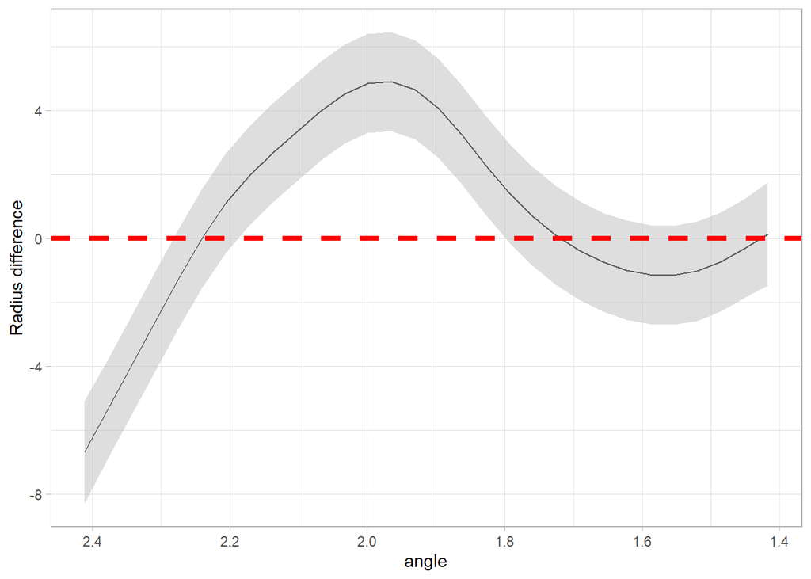

```r
diff_plot_GAM_angle
```

To plot the difference contour `B - A` we have abandoned the radial plot, as differences in radius can be negative, but a negative radius cannot be represented in polar coordinates.

## 1.5 radius ~ angle: FPCA

Here we apply FPCA followed by linear regression to the same dataset we use to estimate GAMs. This procedure is an alternative to GAMs. The procedure is in two steps: First a functional PCA model is estimated on the basis of the dataset, then the model parameters, called *scores*, are used as response variable in a linear regression model, i.e. `lm(score ~ Category)`. The FPCA model describes the independent variations in the entire curve dataset without taking into account the categorical predictors. This provides an overview of all the sources of variation in the data. Then it is our task to identify those sources that are correlated to the relevant predictors (here `Category`). For more information, see Gubian, Torreira & Boves (2015) and the tutorial materials on [this GitHub](https://github.com/uasolo/FPCA-phonetics-workshop/tree/master).

In the code that follows, we use the the same `curves` as the last `radius ~ angle` GAM example, obtained by Procrustean fit. The code is based on the [ex1D.R](https://github.com/uasolo/FPCA-phonetics-workshop/tree/master/scripts) script.

**radius ~ angle: FPCA fit**

```r
# build a funData object
curvesFun <- long2irregFunData(curves, id = "frame_id", time = "angle", value = "radius") %>%
  as.funData()
curvesFun
```

```
Functional data with 60 observations of 1-dimensional support
argvals:
    1.41687 1.516304 ... 2.411207       (11 sampling points)
X:
    array of size 60 x 11
```

```r
# Compute FPCA
fpca <- PACE(curvesFun)

# Prop of explained var
PropExpVar <- round(fpca$values  / sum( fpca$values) , digits = 3)
```

FPCA is computed by the function `MFPCA::PACE()`. As default, it computes a number of PCs covering 99% of the variance. In this case it computed 4 PCs.

We will look at the first two PCs, which explain 79.8% and 12.3% of the variance.

**radius ~ angle: FPCA curves**

```r
nPC <- 2
# scores st. dev.
sdFun <- fpca$values %>% sqrt()
# PC curves to be plotted
PCcurves <- expand_grid(PC = 1:nPC,
                        fractionOfStDev = seq(-1, 1, by=.25)) %>%
  group_by(PC, fractionOfStDev) %>%
  reframe(
    funData2long1(fpca$mu + fractionOfStDev * sdFun[PC] * fpca$functions[PC],
                  time = "angle", value = "radius")
  )
# Plot
FPCA_angle_curves_plot <- ggplot(PCcurves) +
  aes(x = angle, y = radius, group = fractionOfStDev, color = fractionOfStDev) +
  geom_line() +
  scale_color_gradient2(low = "blue", mid = "grey", high = "orangered",
                        breaks = c(-1, 0 , 1)) +
  facet_wrap(~ PC, nrow = 1,
             labeller = labeller(PC = ~ str_glue("PC{.x}"))) +
  labs(color = expression(frac(s[k], sigma[k]))) +
  geom_line(data = PCcurves %>% filter(fractionOfStDev == 0), color = 'black', linewidth = 1.2) +
  radial_plot(60) +
  theme(legend.position = "bottom")
```

Figure 7: First 2 PCs: effect of scores on contour shape

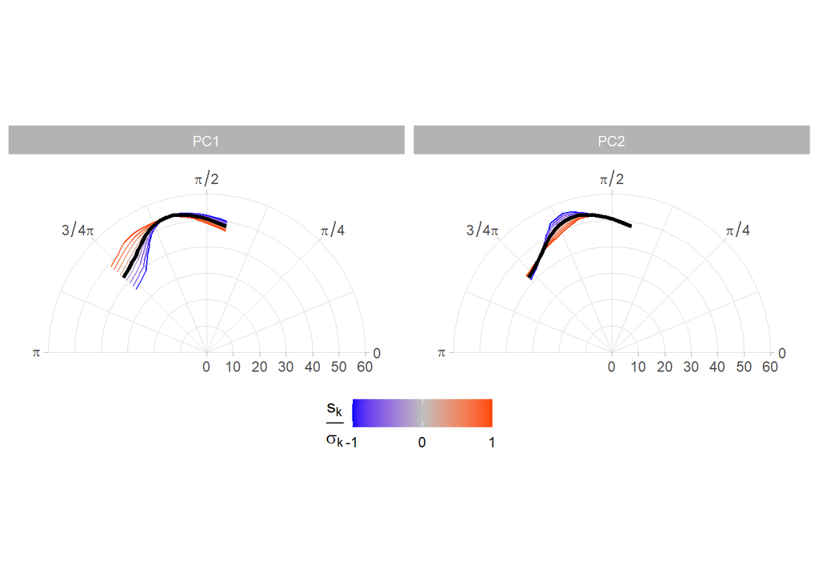

```r
FPCA_angle_curves_plot
```

Each PC captures a different shape variation in the data set, parametrized by a score, (`s1` on the left, `s2` on the right). The black contour is the mean shape, color-coded contours show the relation between scores (normalized by their respective standard deviation) and the shape modelled by the corresponding PC.

In this case we see that PC1 models the large variation towards the left (tongue root), while PC2 models the smaller variation in the middle (tongue dorsum). The two variations are independent, i.e. knowing the value of `s1` does not help guessing the value of `s2`.

This model is estimated without making use of the `Category` values. When we associate back the values of `Category` to scores, we can determine which score correlates with `Category`.

**radius ~ angle: FPCA scores**

```r
# collect PC scores
PCscores <- fpca$scores %>%
  `colnames<-`( paste0("s", 1:fpca$npc)) %>%
  as_tibble() %>%
  bind_cols(curves %>% distinct(frame_id, Category), .)

# boxplots PC scores by Category
FPCA_angle_scores_plot <- PCscores %>%
  pivot_longer(cols = s1:all_of(str_glue("s{fpca$npc}")),
               names_to = "PC", values_to = "score") %>%
  filter(PC %in% str_c("s", 1:nPC)) %>%
  ggplot() +
  aes(x = Category, y = score, color = Category) +
  geom_boxplot() +
  facet_wrap(~ PC) +
  scale_color_manual(values=Category.colors) +
  theme(legend.position = "bottom")
```

Figure 8: Distribution of the first 2 PC scores by Category

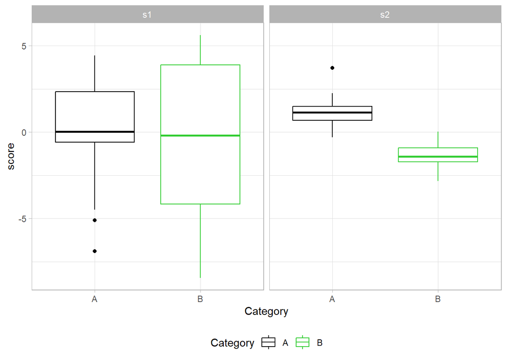

```r
FPCA_angle_scores_plot
```

Clearly `s2` is the score that correlates with `Category`. Note that it is `s2` and not `s1` the score that is more interesting to our analysis, although `s1` is associated to PC1, which by definition explains most of the variance. But this variance is largely independent of the variation correlated to `Category`. In general, it is not guaranteed that there will be exactly one score correlated with a variable of interest: there could be none, one or more than one.

Let us estimate a simple linear model predicting `s2` from `Category`, i.e. `lm(s2 ~ Category)`. Note that this is the simplest possible model, as we do not have multiple predictor or random terms. In realistic cases where these are present, we have to apply a correspondingly more complex model, e.g. using `lme4::lmer()`, but the idea is the same: predict a score based on predictors not used in the estimation of the FPCA model.

**radius ~ angle: FPCA lm**

```r
s <- 2 # score index
model_eq <- str_glue("s{s} ~ Category") %>% as.formula()
mod <- lm(model_eq, data = PCscores)
mod %>% summary()
```

```
Call:
lm(formula = model_eq, data = PCscores)

Residuals:
     Min       1Q   Median       3Q      Max
-1.47535 -0.42984 -0.02173  0.40532  2.58482

Coefficients:
            Estimate Std. Error t value Pr(>|t|)
(Intercept)   1.1219     0.1386   8.097 4.22e-11 ***
CategoryB    -2.4740     0.1960 -12.625  < 2e-16 ***
---
Signif. codes:  0 '***' 0.001 '**' 0.01 '*' 0.05 '.' 0.1 ' ' 1

Residual standard error: 0.7589 on 58 degrees of freedom
Multiple R-squared:  0.7332,    Adjusted R-squared:  0.7286
F-statistic: 159.4 on 1 and 58 DF,  p-value: < 2.2e-16
```

```r
emmeans(mod, pairwise ~ Category)
```

```
$emmeans
 Category emmean    SE df lower.CL upper.CL
 A          1.12 0.139 58    0.845     1.40
 B         -1.35 0.139 58   -1.629    -1.07

Confidence level used: 0.95

$contrasts
 contrast estimate    SE df t.ratio p.value
 A - B        2.47 0.196 58  12.625  <.0001
```

```r
# reconstruct predicted curves
predCurves <- emmeans(mod, pairwise ~ Category)$emmeans %>%
  as_tibble() %>%
  group_by(Category) %>%
  reframe(bind_cols(
    funData2long1(fpca$mu + emmean * fpca$functions[s], time = 'angle', value = "radius"),
    funData2long1(fpca$mu + lower.CL * fpca$functions[s], time = 'angle', value = "yl") %>%
      select(yl),
    funData2long1(fpca$mu + upper.CL * fpca$functions[s], time = 'angle', value = "yu") %>%
      select(yu)
  ))

FPCA_angle_pred_plot <- ggplot(predCurves) +
  aes(angle, radius, color = Category) +
  geom_line() +
  geom_ribbon(aes(x = angle, ymin = yl, ymax = yu, fill = Category),
              alpha = 0.3, inherit.aes = FALSE) +
  scale_color_manual(values=Category.colors) +
  scale_fill_manual(values=Category.colors) +
  radial_plot(60) +
  theme(legend.position = "bottom")

# diff curve B - A
diffCurve <- emmeans(mod, pairwise ~ Category)$contrasts %>%
  as_tibble() %>%
  reframe(bind_cols(
# emmeans computes A - B, so we need to invert the sign of all curves
    funData2long1(-estimate * fpca$functions[s], time = "angle", value = "radius"),
    funData2long1(-(estimate - 1.96 * SE) * fpca$functions[s], time = "angle", value = "radius_l") %>%
      select(radius_l),
    funData2long1(-(estimate + 1.96 * SE) * fpca$functions[s], time = "angle", value = "radius_u") %>%
      select(radius_u)
  ))

FPCA_angle_diff_plot <- ggplot(diffCurve) +
  aes(angle, radius) +
  geom_line() +
  geom_ribbon(aes(x = angle, ymin = radius_l, ymax = radius_u),
              alpha = 0.3, inherit.aes = FALSE) +
  geom_hline(yintercept = 0, linetype = "dashed", color = 'red') +
  scale_x_reverse() +
  ylab("Radius difference")
```

Figure 9: Reconstructed contours by Category, based on regression model: s2 ~ Category

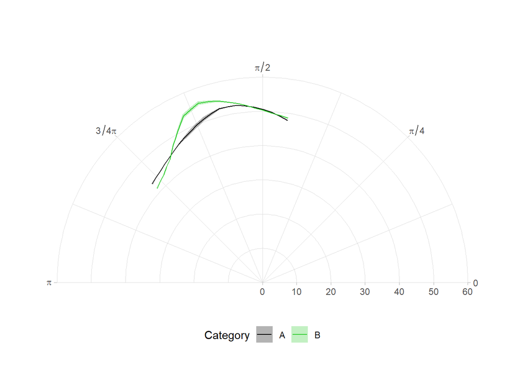

```r
FPCA_angle_pred_plot
```

Figure 10: Difference curve B - A, based on regression model: s2 ~ Category

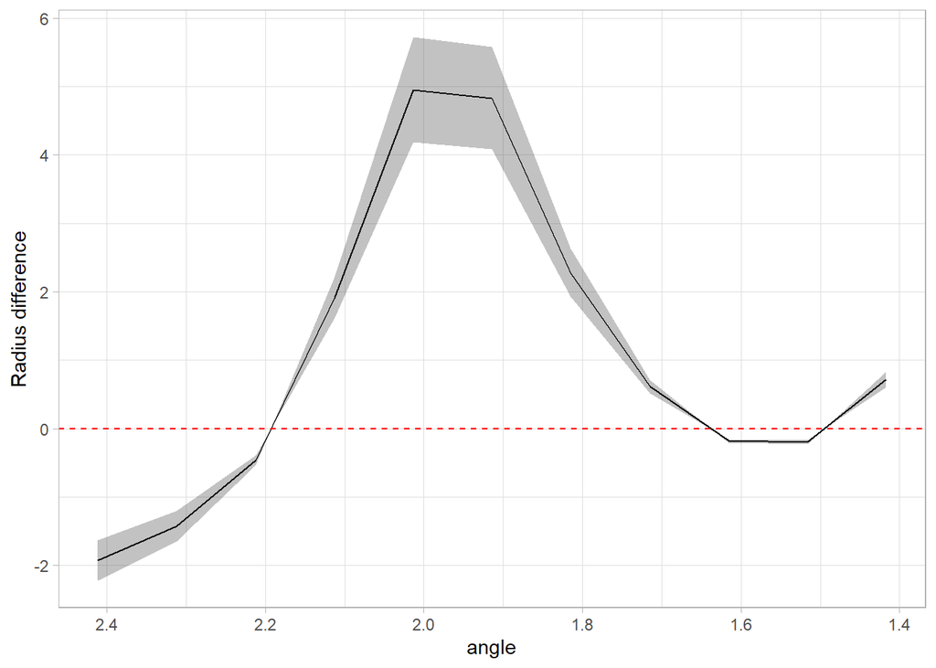

```r
FPCA_angle_diff_plot
```

The shape of the predicted curves is similar to those obtained with the GAM. Comparing the difference curve obtained with FPCA with the one in Figure 6 obtained with the GAM, we see that the shape is similar, while the confidence intervals are very different. The confidence interval of the GAM-based difference curve reflects local similarities, i.e. measured at the same point on the `angle` axis, while the confidence interval of the FPCA-based difference curve reflects the uncertainty in the estimation of the difference between levels `A` and `B` in the `lm(s2 ~ Category)` model modulated by the shape of the PC2 curve. It is probably not advisable to use the FPCA-based confidence intervals to perform localized inference, i.e. determine whether contours `A` and `B` differ significantly at a specific `angle` location, as these do not reflect local properties directly. Difference curves obtained from FPCA will not be shown further on.

## 1.6 (x, y) ~ knot: GAM

Here we consider the alternative geometric parametrization consisting in using the knots as independent axis and setting up a multivariate (or multiresponse) model that predicts two values, `x` and `y`, given `knot`. This approach is also showcased in Coretta & Sakr (2025) on real UTI data, applying both GAMs and FPCA.

### 1.6.1 Multivariate GAM

The canonical way to construct a multivariate GAM is to set up a system of two parallel models, one predicting `x` and one predicting `y`. This is possible using `mgcv::gam()`.

**Multivariate GAM fit**

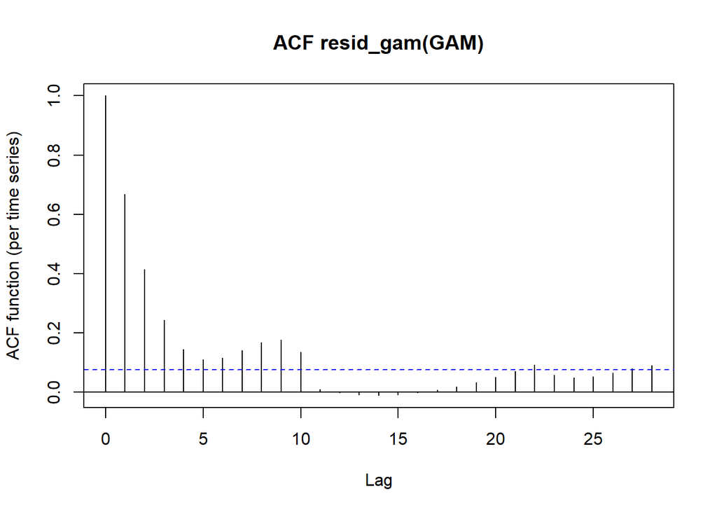

```r
GAM <- gam(list(x ~ Category + s(knot, by = Category, k = 5),
                y ~ Category + s(knot, by = Category, k = 5)
                ),
            family=mvn(d = 2),
            data = raw_curves
)
AR1.rho <- acf_resid(GAM)[2]
```

```r
GAM <- gam(list(x ~ Category + s(knot, by = Category, k = 5),
                y ~ Category + s(knot, by = Category, k = 5)
                ),
            family=mvn(d = 2),
            rho = AR1.rho,
            AR.start = raw_curves %>% pull(knot)  == 1,
            data = raw_curves
)
summary(GAM)
```

```
Family: Multivariate normal
Link function:

Formula:
x ~ Category + s(knot, by = Category, k = 5)
y ~ Category + s(knot, by = Category, k = 5)

Parametric coefficients:
              Estimate Std. Error z value Pr(>|z|)
(Intercept)   61.24836    0.17851 343.113   <2e-16 ***
CategoryB     -7.04112    0.25245 -27.891   <2e-16 ***
(Intercept).1 76.39509    0.09741 784.300   <2e-16 ***
CategoryB.1    0.29365    0.13775   2.132    0.033 *
---
Signif. codes:  0 '***' 0.001 '**' 0.01 '*' 0.05 '.' 0.1 ' ' 1

Approximate significance of smooth terms:
                      edf Ref.df Chi.sq p-value
s(knot):CategoryA   3.215  3.671   5929  <2e-16 ***
s(knot):CategoryB   3.559  3.887   3775  <2e-16 ***
s.1(knot):CategoryA 3.975  4.000   4747  <2e-16 ***
s.1(knot):CategoryB 3.974  3.999   6342  <2e-16 ***
---
Signif. codes:  0 '***' 0.001 '**' 0.01 '*' 0.05 '.' 0.1 ' ' 1

Deviance explained = 94.7%
-REML = 1855.4  Scale est. = 1         n = 660
```

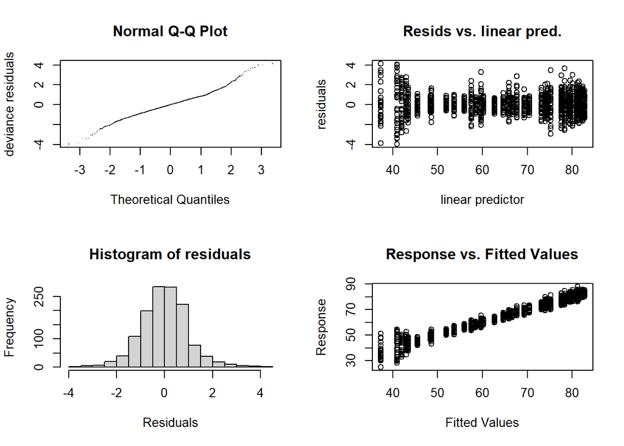

```
Method: REML   Optimizer: outer newton
full convergence after 17 iterations.
Gradient range [-0.0007176559,0.0009222604]
(score 1855.407 & scale 1).
Hessian positive definite, eigenvalue range [1.328535,1.92555].
Model rank =  23 / 23

Basis dimension (k) checking results. Low p-value (k-index<1) may
indicate that k is too low, especially if edf is close to k'.

                      k'  edf k-index p-value
s(knot):CategoryA   4.00 3.22    0.99    0.38
s(knot):CategoryB   4.00 3.56    0.99    0.30
s.1(knot):CategoryA 4.00 3.98    0.99    0.34
s.1(knot):CategoryB 4.00 3.97    0.99    0.29
```

```r
gam.check(GAM)
```

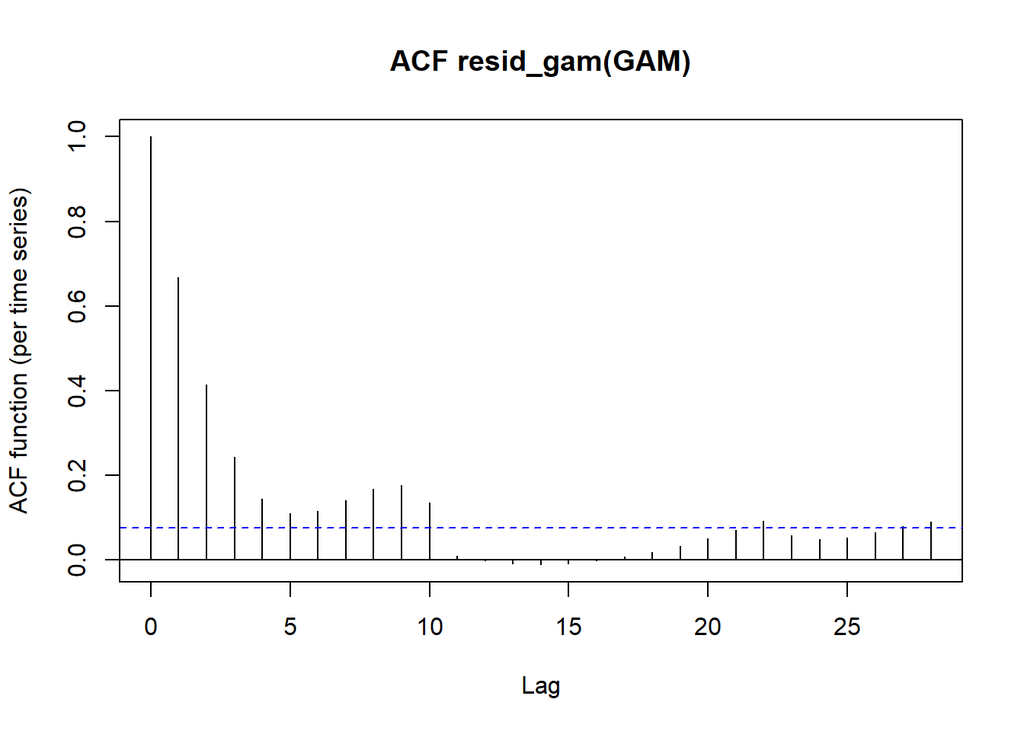

```r
acf_resid(GAM)
```

The model diagnostic shows that the residuals are clearly non-Gaussian. However, there is no remedy to this within the `mgcv` library, as multivariate GAMs are implemented only for the Gaussian case (`family=mvn(d = 2)`). Besides that, there are no clear advantages of setting up this type of model with `mgcv` since there are no functions that allow to estimate any multivariate inference, i.e. taking `x` and `y` into consideration jointly and not separately.

There are other R libraries that implement multivariate GAMs: [mvgam](https://cran.r-project.org/web/packages/mvgam/index.html) and [gmfamm](https://cran.r-project.org/web/packages/gmfamm/index.html), both Bayesian. These are not explored here.

### 1.6.2 Univariate trick

An alternative approach is to apply the trick used in Wieling et al. (2016). The trick consists in creating a factor that encodes the coordinate axis, i.e. factor `Dimension` with two levels: `x` and `y`. Then use a regular, univariate GAM where the response variable is `Position`, which means `x` or `y` depending on the value of the ‘predictor’ `Dimension`. The advantage is that the model architecture is simpler, as it avoids the complexity of the double response variable, and that non-Gaussian models are available (here we will use `scat` as in the previous examples). The downside is that this is a sub-optimal model in that correlations across `x` and `y` dimension are not taken into account, and that adding a factor complicates the model equation (more on how to handle multiple factors in GAMs can be found in Wieling (2018) and in [GAMInteractions](https://github.com/uasolo/FPCA-phonetics-workshop/tree/master/presentations/GAMs)).

**Univariate trick fit**

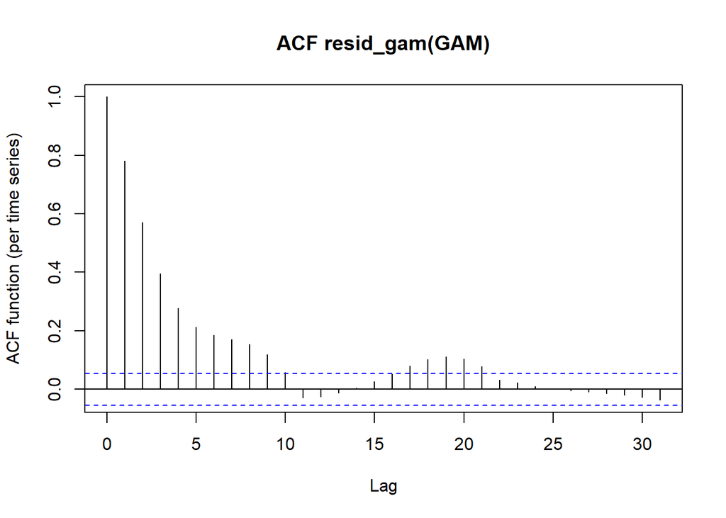

```r
# Create a compound factor Cat_Dim for all combos of Category and Dimension
raw_curves_long <- raw_curves %>%
             pivot_longer(c(x, y), names_to = 'Dimension', values_to = 'Position') %>%
             unite("Cat_Dim", c(Category, Dimension)) %>%
             mutate(Cat_Dim = factor(Cat_Dim)) %>%
             # order to capture AR along knots
             arrange(frame_id, Cat_Dim, knot)
GAM <- bam(Position ~ Cat_Dim + s(knot, by = Cat_Dim),
           data = raw_curves_long,
           family = 'scat',
           discrete = TRUE)
AR1.rho <- acf_resid(GAM)[2]
```

```r
GAM <- bam(Position ~ Cat_Dim + s(knot, by = Cat_Dim),
           data = raw_curves_long,
           rho = AR1.rho,
            AR.start = raw_curves_long %>% pull(knot)  == 1,
           family = 'scat',
           discrete = TRUE)
summary(GAM)
```

```
Family: Scaled t(3.678,1.778)
Link function: identity

Formula:
Position ~ Cat_Dim + s(knot, by = Cat_Dim)

Parametric coefficients:
            Estimate Std. Error t value Pr(>|t|)
(Intercept)  60.3809     0.2697  223.88   <2e-16 ***
Cat_DimA_y   15.6368     0.3817   40.97   <2e-16 ***
Cat_DimB_x   -6.6068     0.3815  -17.32   <2e-16 ***
Cat_DimB_y   15.8917     0.3817   41.64   <2e-16 ***
---
Signif. codes:  0 '***' 0.001 '**' 0.01 '*' 0.05 '.' 0.1 ' ' 1

Approximate significance of smooth terms:
                     edf Ref.df      F p-value
s(knot):Cat_DimA_x 5.633  7.053 1045.2  <2e-16 ***
s(knot):Cat_DimA_y 8.323  8.901  352.2  <2e-16 ***
s(knot):Cat_DimB_x 6.448  7.801  561.0  <2e-16 ***
s(knot):Cat_DimB_y 8.290  8.891  416.2  <2e-16 ***
---
Signif. codes:  0 '***' 0.001 '**' 0.01 '*' 0.05 '.' 0.1 ' ' 1

R-sq.(adj) =  0.966   Deviance explained = 85.7%
fREML = 1653.7  Scale est. = 1         n = 1320
```

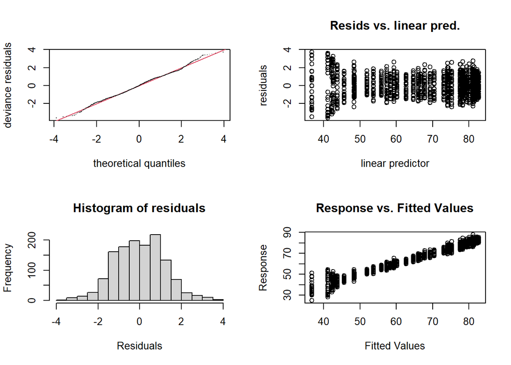

```
Method: fREML   Optimizer: perf chol
$grad
[1] 3.465450e-11 2.866596e-12 5.152989e-11 1.560085e-12

$hess
              [,1]          [,2]          [,3]          [,4]
[1,]  2.774595e+00 -2.199663e-19 -8.380310e-19 -7.552351e-19
[2,] -1.495870e-19  3.869857e+00 -4.998815e-35  8.258490e-34
[3,]  1.177214e-19 -2.244319e-34  3.201291e+00 -2.286605e-34
[4,] -1.605691e-19  6.536545e-34 -4.990411e-35  3.864592e+00

Model rank =  40 / 40

Basis dimension (k) checking results. Low p-value (k-index<1) may
indicate that k is too low, especially if edf is close to k'.

                     k'  edf k-index p-value
s(knot):Cat_DimA_x 9.00 5.63    1.03    0.86
s(knot):Cat_DimA_y 9.00 8.32    1.03    0.85
s(knot):Cat_DimB_x 9.00 6.45    1.03    0.84
s(knot):Cat_DimB_y 9.00 8.29    1.03    0.88
```

```r
gam.check(GAM)
```

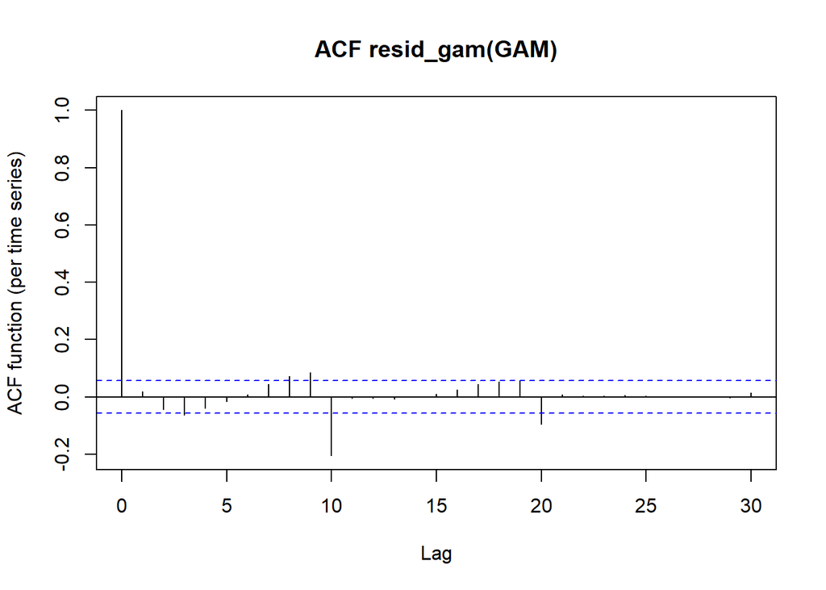

```r
acf_resid(GAM)
```

```r
pred <- get_predictions(GAM,
                        cond = list(knot = 1:11,
                                    Cat_Dim = raw_curves_long$Cat_Dim %>% levels()),
                        se = FALSE,
                        print.summary = FALSE) %>%
  separate_wider_delim(Cat_Dim, "_", names = c("Category", "Dimension")) %>%
  pivot_wider(names_from = Dimension, values_from = "fit")
gam_trick_pred_plot <- ggplot(pred) +
  aes(x, y, group = Category, color = Category) +
  geom_path() +
  geom_point(color='red') +
  geom_text(aes(label = knot), check_overlap = TRUE,
            nudge_x = .9, nudge_y = .9, show.legend = FALSE) +
  scale_color_manual(values=Category.colors) +
  theme(legend.position = "bottom")
```

Figure 11: Univariate trick GAM: predictions

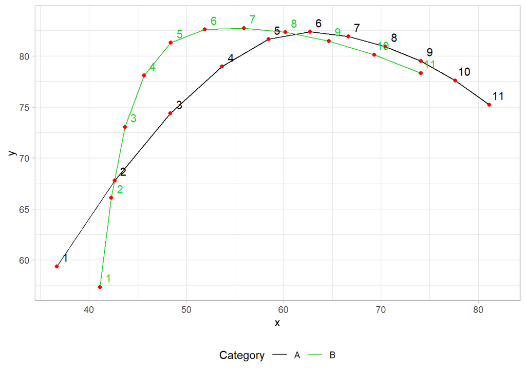

```r
gam_trick_pred_plot
```

The predictions are faithful to the original dataset. The advantage of the multivariate parametrization, even when implementing the workaround to avoid fitting an actual multivariate GAM, is that knots (indicated in red) preserve their original position when used to fit the model, while in the polar coordinate approach the knots were re-interpolated and lost their interpretable value.

The difference curves for `Category` `B - A` are computed separately by dimension `x` and `y`:

Figure 12: Difference curves B - A, separated by dimension x, y

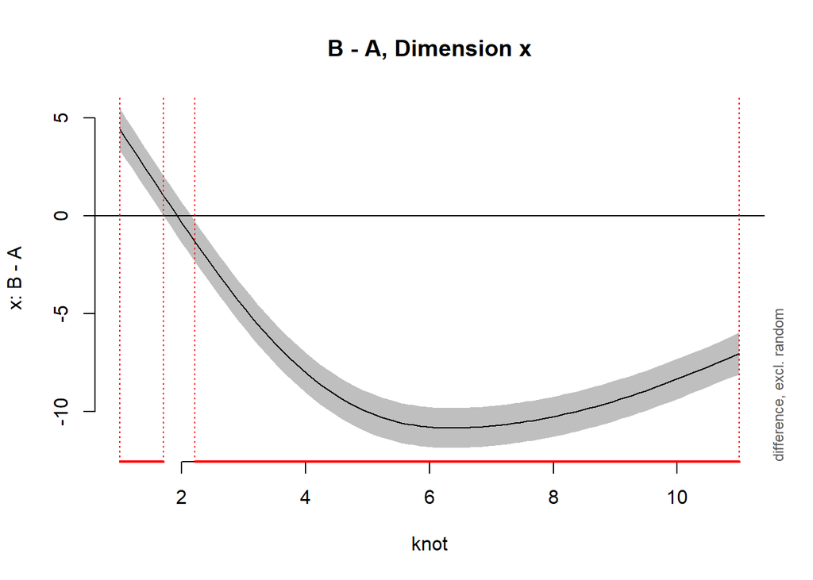

Figure 13: Difference curves B - A, separated by dimension x, y

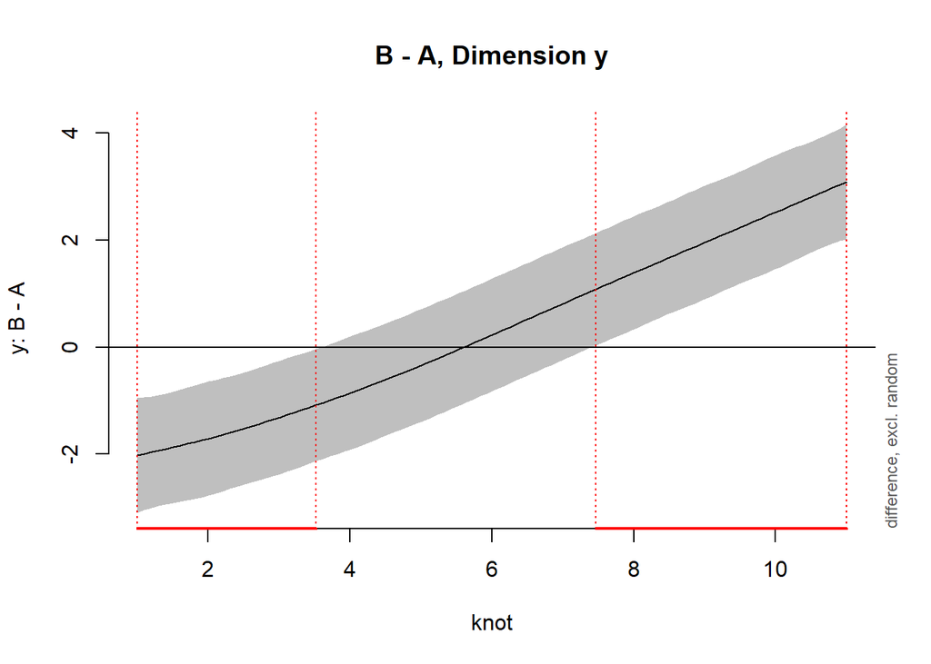

```r
plot_diff(GAM, view = "knot", comp = list(Cat_Dim = c("B_x", "A_x")),
            print.summary = FALSE, main = "B - A, Dimension x", ylab = "x: B - A")
plot_diff(GAM, view = "knot", comp = list(Cat_Dim = c("B_y", "A_y")),
            print.summary = FALSE, main = "B - A, Dimension y", ylab = "y: B - A")
```

Two considerations for the interpretation of results in this setting.

- For a given knot, if at least one difference curve shows a significant difference, then we can say the contours are different at that knot. For example, the difference between `A` and `B` on the `y` axis is not significant for knots 4 to 7, while it is on the `x` axis. In fact, those corresponding knots are at about the same height (`y`), while `A` knots are clearly more fronted (`x`) than `B` knots, which means they are in a different location.
- If two knots with a different index are close to each other, this is not revealed by the difference curves. For example, knot 9 `A` and knot 11 `B` are very close to each other, but since they have different indices this does not show in the difference curves. Compare this to the difference curve Figure 6 obtained from the angle-based approach: In the knot-based case `A` and `B` are indicated as separated towards high values of knot (tongue tip), while in the angle-based case `A` and `B` are indicated overlapping towards low values of angle (tongue tip).